# Fast Design of High Order Portfolios

Daniel P. Palomar and Rui Zhou The Hong Kong University of Science and Technology (HKUST)

2020-07-27

# Quick Start

Let’s start by loading the package:

```r
library(highOrderPortfolios)
# ?design_MVSK_portfolio  # to get help for the function
```

```r
# load the embedded dataset
data(X50)
str(X50)
```

```
#>  num [1:250, 1:50] -0.0511 0.0151 -0.061 0.0561 -0.0387 ...
#>  - attr(*, "dimnames")=List of 2
#>   ..$ : NULL
#>   ..$ : NULL
```

```r
# estimate moments
X_moments <- estimate_moments(X50, adjust_magnitude = TRUE)

# decide problem setting
w0 <- rep(1/50, 50)
w0_moments <- eval_portfolio_moments(w0, X_moments)
d <- abs(w0_moments)
kappa <- sqrt(w0%*%X_moments$Sgm%*%w0) * 0.3

# portfolio optimization
sol <- design_MVSKtilting_portfolio(d, X_moments, w_init = w0, w0 = w0,
                                    w0_moments = w0_moments, kappa = kappa, ftol = 1e-10)
```

Let’s take a look at the result:

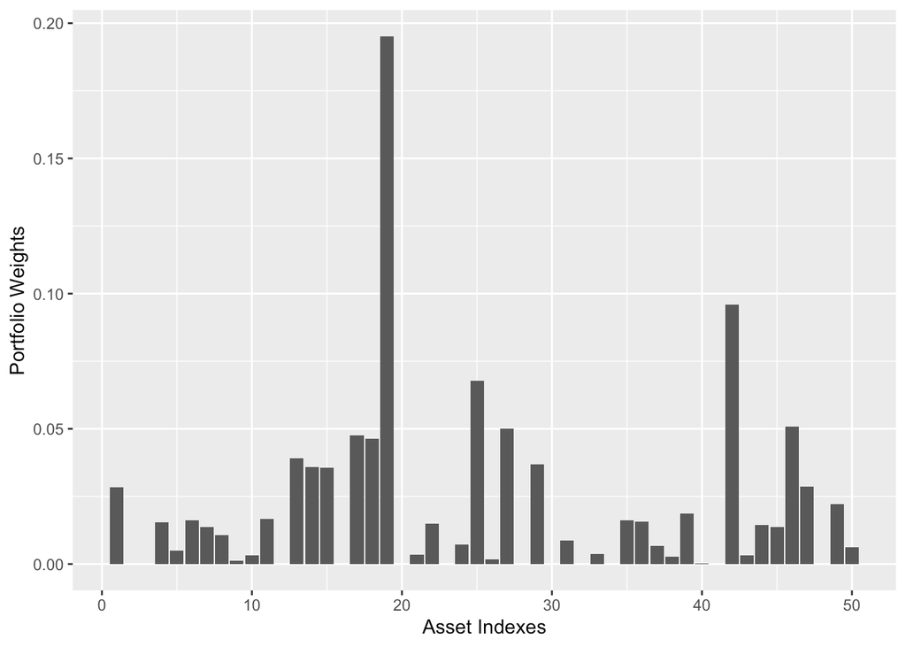

```r
# plot
require(ggplot2)
require(magrittr)

data.frame(idx = 1:ncol(X50), weights = sol$w) %>%
  ggplot(aes(x = idx, y = weights)) +
  geom_bar(stat = "identity") +
  labs(x = "Asset Indexes", y = "Portfolio Weights")
```

# What is the High-order Portfolio?

## Signal model

Let us denote by $\mathbf{r}_{t}$ the vector of the **returns** of $N$ assets at time $t$ and suppose they follow an i.i.d. distribution (which is not a totally accurate assumption, but it is widely adopted, nonetheless) with mean $\boldsymbol{\mu}$ and covariance matrix $\boldsymbol{\Sigma}$.

The portfolio vector $\mathbf{w}$ denotes the normalized dollar weights allocated to the $N$ assets, and the **portfolio return** is then $r_{t}^{\sf portf} = \mathbf{w}^{T}\mathbf{r}_{t}$, with expected return $\mathbf{w}^{T}\boldsymbol{\mu}$ and variance $\mathbf{w}^{T}\boldsymbol{\Sigma}\mathbf{w}$.

## Modern Portfolio Theory

In 1952, Markowitz proposed in his seminal paper [1] to find a trade-off between the portfolio expected return and its risk measured by the variance:
$$\begin{array}{ll}
\underset{\mathbf{w}}{\textsf{maximize}} & \mathbf{w}^{T}\boldsymbol{\mu}-\lambda\mathbf{w}^{T}\boldsymbol{\Sigma}\mathbf{w}\\
\textsf{subject to} & \mathbf{w} \ge \mathbf{0}, \quad\mathbf{1}^T\mathbf{w}=1,
\end{array}$$
where $\lambda$ is a parameter that controls how risk-averse the investor is.

Markowitz’s portfolio has been heavily critized for over half a century and has never been fully embraced by practitioners, among many reasons because:

- Mean and variance of the portfolio return are good measures when it is Gaussian distributed. But the empirical distribution of the portfolio return is usually asymmetric and heavy-tailed, which can not be well described by only mean and variance.
- The objective $\mathbf{w}^{T}\boldsymbol{\mu}-\lambda\mathbf{w}^{T}\boldsymbol{\Sigma}\mathbf{w}$ assumes investors have a taste for the quadratic expected utility function on portfolio return. But investors’ tastes might be very different.

## From Mean-Variance Portfolio to High-order Portfolio

To make up the drawbacks of the mean-variance framework, we need to take high-order moments of the portfolio return into consideration. It admits the following advantages:

- The asymmetry and heavy-tailedness of portfolio return are well captured by its third and fourth central moments, i.e., skewness and kurtosis.
- Incorporating high-order moments of the portoflio return can approximates a general expected utility function better with its Taylor series expansion truncated to the four most important order terms.

Generally speaking, a higher skewness usually means that the portfolio return admits a more positively skewed shape, while the lower kurtosis usually corresponds to thinner tail. We can extend the mean-variance framework by directly incorporating the high-order moments to obtain the mean-variance-skewness-kurtosis (MVSK) framework, where we shall try to strike a balance between maximizing the mean and skewness (odd moments) while minimizing the variance and kurtosis (even moments).

## High-order Portfolios

This package implements the algorithms designed in the paper [2]. The two main problem formulations covered in that paper are mean-variance-skewness-kurtosis (MVSK) and mean-variance-skewness-kurtosis tilting (MVSKT) problems.

### MVSK Tilting Portfolio

Another formulation for the high-order portfolio is putting the high-order consideration into constraints. We study the algorithm for solving, for example, the MVSK tilting portfolio [3]:
$$\begin{aligned}\underset{\mathbf{w},\delta}{\mathsf{maximize}}\,\, & \quad\delta\\
\mathsf{subject\,\,to} & \quad\phi_{1}\left(\mathbf{w}\right)\ge\phi_{1}\left(\mathbf{w}_{0}\right)+d_{1}\delta,\\
& \quad\phi_{2}\left(\mathbf{w}\right)\le\phi_{2}\left(\mathbf{w}_{0}\right)-d_{2}\delta,\\
& \quad\phi_{3}\left(\mathbf{w}\right)\ge\phi_{3}\left(\mathbf{w}_{0}\right)+d_{3}\delta,\\
& \quad\phi_{4}\left(\mathbf{w}\right)\le\phi_{4}\left(\mathbf{w}_{0}\right)-d_{4}\delta,\\
& \quad\left(\mathbf{w}-\mathbf{w}_{0}\right)^{T}\boldsymbol{\Sigma}\left(\mathbf{w}-\mathbf{w}_{0}\right)\le\kappa^{2},\\
& \quad\mathbf{w}\in\mathcal{W},\delta\ge0,
\end{aligned}$$
where $\mathbf{d}=\left[d_{1},d_{2},d_{3},d_{4}\right]\ge\mathbf{0}$ is the tilting direction, $\kappa^{2}$ determines the maximum tracking error volatility of $\mathbf{w}$ with respect to the reference portfolio $\mathbf{w}_{0}$.

# Using the Package highOrderPortfolios

## Estimate the High-order Comoment Matrix

Unlike the mean and covariance matrix, the coskewness and cokurtosis matrix are rarely estimated. The basic R does not provide an embedded function for estimating them. Therefore, we conclude a function `estimate_moments()` in this package to help estimate the sample coskewness and cokurtosis matrix. A simple code example is presented as follows:

```r
library(highOrderPortfolios)

# load the embedded dataset
data(X50)

# estimate moments
X_moments <- estimate_moments(X50)
names(X_moments)
```

```
#> [1] "mu"        "Sgm"       "Phi"       "Psi"       "Phi_shred" "Psi_shred"
```

## MVSK Portfolio

A simple code example for solving the MVSK portfolio is presented as follows:

```r
# decide moment weights
xi <- 10
lmd <- c(1, xi/2, xi*(xi+1)/6, xi*(xi+1)*(xi+2)/24)

# portfolio optimization
sol <- design_MVSK_portfolio(lmd, X_moments)
```

Check the optimized MVSK portfolio:

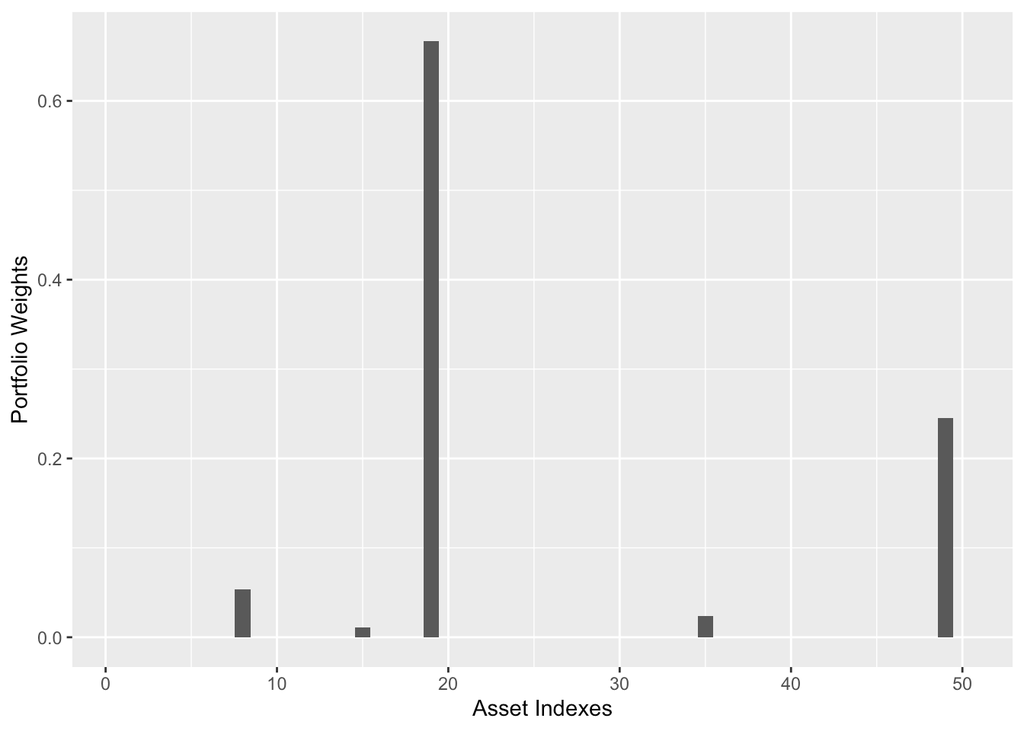

```r
data.frame(idx = 1:ncol(X50), weights = sol$w) %>%
  ggplot(aes(x = idx, y = weights)) +
  geom_bar(stat = "identity") +
  labs(x = "Asset Indexes", y = "Portfolio Weights")
```

## MVSK Tilting Portfolio

```r
sol$improve  # the improvement of moments of the designed portfolio
```

```
#>      mean  variance  skewness  kurtosis
#> 0.4657068 0.4657068 0.5988725 0.6908227
```

[figure not shown]

```r
data.frame(idx = 1:ncol(X50), weights = sol$w) %>%
  ggplot(aes(x = idx, y = weights)) +
  geom_bar(stat = "identity") +
  labs(x = "Asset Indexes", y = "Portfolio Weights")
```

# References

[1] H. Markowitz, “Portfolio selection,” *J. Financ.*, vol. 7, no. 1, pp. 77–91, 1952.

[2] R. Zhou and D. P. Palomar, “Solving high-order portfolios via successive convex approximation algorithms.” 2020.

[3] K. Boudt, D. Cornilly, F. V. Holle, and J. Willems, “Algorithmic portfolio tilting to harvest higher moment gains,” *Heliyon*, vol. 6, no. 3, p. e03516, 2020.